# R Notebook

Начальная инициализациия. Достаём данные, считаем по ним какие-то статистики. Оцениваем максимальное MSR. Добавляем biclust и заводим переменную l для бикластеорв.

```r
#INIT
library(multtest)
data(golub)
max_val<-max(golub)
min_val<-min(golub)
max_delta <- ((max_val-min_val)**2)/12
mean_val<-mean(golub)
med_val <- median(golub)
cat(max_delta)
```

```
2.526235
```

```r
library(biclust)
rm(l)
```

```
object 'l' not found
```

```r
l=list()
```

```r
str(var(golub))
```

```
 num [1:38, 1:38] 1 0.69 0.74 0.796 0.717 ...
```

Применим алгоритм CC. Определение параметров: Если матрица получена случайным выбором значений из отрезка [a,b] , то её дельта параметр не больше чем (b-a)2/12. В нашем случае это 2.526235. Альфа как и в оригинальной статье 1.2.

```r
#CHENG AND CHURCH
start_d =0.001
end_d=1
step_d=0.01
cc_count =(end_d-start_d)/step_d +1
print(cc_count)
```

```
[1] 100.9
```

```r
cc_num= 5
cc_al=1.2
l=list()
for (cc in (0:(cc_count-1))){
  d=start_d + cc * step_d
  bic=biclust(golub, method=BCCC(), delta=d, alpha=cc_al, number=cc_num)
  for (bic_num in biclusternumber(bic, number= 1:bic@Number)){
    elem = list("CC", bic_num$Rows,bic_num$Cols, list(d,cc_al) )
    names(elem)<- c("alg","rows","cols","params")
    l<-c(l,list(elem))

  }

}
 cat("общее количество бикластеров:",length(l))
```

```
общее количество бикластеров: 236
```

Применим BiMax для поиска бикластеров. Сначала бинаризуем данные, вызвав соответствующую функцию, а затем уже запустим алгоритм. Кроме того, зададим минимальный размер бикластера как 3 на 3,т.к. нас не интересуют совсем тривиальные случаи.

```r
#bimax
bimax_minr=3
bimax_minc=3
bimax_num=50
bin_data <- binarize(golub,2)
res <- biclust(x=bin_data, method=BCBimax(), minr=bimax_minr, minc=bimax_minc, number=bimax_num)
for (bic_num in biclusternumber(bic, number= 1:bic@Number)){
    elem = list("BiMax", bic_num$Rows, bic_num$Cols, list(bimax_minr,bimax_minc,bimax_num))
    names(elem)<- c("alg","rows","cols","params")
    l<-c(l,list(elem))
}
 cat("общее количество бикластеров:",length(l))
```

```
общее количество бикластеров: 237
```

Запустим версию BiMax, которая ограничена сверху по числу столбцов в бикластере. Нас не интересуют очень маленькие или очень большие бикластеры. Т.к. мы надеемся посмотреть связь с изначальными классами пациентов.

```r
#bimax c ограниченным числом столбцов ???
bimax_minr=3
bimax_minc=3
bimax_maxc=20
bimax_num=10
bin_data <- binarize(golub,2)
for (bimax_col in (5:20)){
  res <- biclust(x=bin_data, method=BCrepBimax(), minr=bimax_minr, minc=bimax_minc, number=bimax_num,maxc=bimax_col)
  for (bic_num in biclusternumber(bic, number= 1:bic@Number)){
    elem = list("BCrepBimax", bic_num$Rows,bic_num$Cols, list(bimax_minr,bimax_minc,bimax_col,bimax_num) )
    names(elem)<- c("alg","rows","cols","params")
    l<-c(l,list(elem))

  }
}
cat("общее количество бикластеров:",length(l))
```

```
общее количество бикластеров: 253
```

Используем также алгоритм Fabia

```r
library(fabia)
fab_count= 5
fab_num=10
fab_sp_step=0.1
for( i in  (1:fab_count)){
  res<- fabia(X =golub,cyc = 500,p = fab_num,center=1,norm=1 )
  rb <- extractBic(res)
  for (fab_ind in (1:fab_num)){
    elem = list("fabia", rb$numn[fab_ind,]$numng,rb$numn[fab_ind,]$numnp, list(500,fab_num))
    names(elem)<- c("alg","rows","cols","params")
    l<-c(l,list(elem))

  }
}
```

```
Running FABIA on a 3051x38 matrix with
   Number of biclusters ---------------- p: 10
   Sparseness factor --------------- alpha: 0.01
   Number of iterations -------------- cyc: 500
   Loading prior parameter ----------- spl: 0
   Factor prior parameter ------------ spz: 0.5
   Initialization loadings--------- random: 1 = interval
   Nonnegative Loadings and Factors ------: 0 = No
   Centering ---------------------- center: 1 = mean
   Quantile scaling (0.75-0.25): ---- norm: 1 = Yes
   Scaling loadings per iteration -- scale: 0 = No
   Constraint variational parameter -- lap: 1
   Max. number of biclusters per row -- nL: 0 = no limit
   Max. number of row elements / biclu. lL: 0 = no limit
```

[output not shown]

```
Running FABIA on a 3051x38 matrix with
   Number of biclusters ---------------- p: 10
   Sparseness factor --------------- alpha: 0.01
   Number of iterations -------------- cyc: 500
   Loading prior parameter ----------- spl: 0
   Factor prior parameter ------------ spz: 0.5
   Initialization loadings--------- random: 1 = interval
   Nonnegative Loadings and Factors ------: 0 = No
   Centering ---------------------- center: 1 = mean
   Quantile scaling (0.75-0.25): ---- norm: 1 = Yes
   Scaling loadings per iteration -- scale: 0 = No
   Constraint variational parameter -- lap: 1
   Max. number of biclusters per row -- nL: 0 = no limit
   Max. number of row elements / biclu. lL: 0 = no limit
```

[output not shown]

```
Running FABIA on a 3051x38 matrix with
   Number of biclusters ---------------- p: 10
   Sparseness factor --------------- alpha: 0.01
   Number of iterations -------------- cyc: 500
   Loading prior parameter ----------- spl: 0
   Factor prior parameter ------------ spz: 0.5
   Initialization loadings--------- random: 1 = interval
   Nonnegative Loadings and Factors ------: 0 = No
   Centering ---------------------- center: 1 = mean
   Quantile scaling (0.75-0.25): ---- norm: 1 = Yes
   Scaling loadings per iteration -- scale: 0 = No
   Constraint variational parameter -- lap: 1
   Max. number of biclusters per row -- nL: 0 = no limit
   Max. number of row elements / biclu. lL: 0 = no limit
```

[output not shown]

```
Running FABIA on a 3051x38 matrix with
   Number of biclusters ---------------- p: 10
   Sparseness factor --------------- alpha: 0.01
   Number of iterations -------------- cyc: 500
   Loading prior parameter ----------- spl: 0
   Factor prior parameter ------------ spz: 0.5
   Initialization loadings--------- random: 1 = interval
   Nonnegative Loadings and Factors ------: 0 = No
   Centering ---------------------- center: 1 = mean
   Quantile scaling (0.75-0.25): ---- norm: 1 = Yes
   Scaling loadings per iteration -- scale: 0 = No
   Constraint variational parameter -- lap: 1
   Max. number of biclusters per row -- nL: 0 = no limit
   Max. number of row elements / biclu. lL: 0 = no limit
```

[output not shown]

```
Running FABIA on a 3051x38 matrix with
   Number of biclusters ---------------- p: 10
   Sparseness factor --------------- alpha: 0.01
   Number of iterations -------------- cyc: 500
   Loading prior parameter ----------- spl: 0
   Factor prior parameter ------------ spz: 0.5
   Initialization loadings--------- random: 1 = interval
   Nonnegative Loadings and Factors ------: 0 = No
   Centering ---------------------- center: 1 = mean
   Quantile scaling (0.75-0.25): ---- norm: 1 = Yes
   Scaling loadings per iteration -- scale: 0 = No
   Constraint variational parameter -- lap: 1
   Max. number of biclusters per row -- nL: 0 = no limit
   Max. number of row elements / biclu. lL: 0 = no limit
```

[output not shown]

```r
cat("общее количество бикластеров:",length(l))
```

[output not shown]

```r
#модернизация с разреженностью
for( i in  (1:fab_count)){
  res<- fabias(X =golub,alpha= fab_sp_step*i,cyc = 500,p = fab_num,center=1,norm=1 )
  rb <- extractBic(res)
  for (fab_ind in (1:fab_num)){
    elem = list("fabias", rb$numn[fab_ind,]$numng,rb$numn[fab_ind,]$numnp, list(500,fab_num))
    names(elem)<- c("alg","rows","cols","params")
    l<-c(l,list(elem))

  }
}
```

```
Running FABIAS on a 3051x38 matrix with
   Number of biclusters ---------------- p: 10
   Sparseness projection factor ---- alpha: 0.1
   Number of iterations -------------- cyc: 500
   Factor prior parameter ------------ spz: 0.5
   Initialization loadings--------- random: 1 = interval
   Nonnegative Loadings and Factors ------: 0 = No
   Centering ---------------------- center: 1 = mean
   Quantile scaling (0.75-0.25): ---- norm: 1 = Yes
   Constraint variational parameter -- lap: 1
   Max. number of biclusters per row -- nL: 0 = no limit
   Max. number of row elements / biclu. lL: 0 = no limit
```

[output not shown]

```
Running FABIAS on a 3051x38 matrix with
   Number of biclusters ---------------- p: 10
   Sparseness projection factor ---- alpha: 0.2
   Number of iterations -------------- cyc: 500
   Factor prior parameter ------------ spz: 0.5
   Initialization loadings--------- random: 1 = interval
   Nonnegative Loadings and Factors ------: 0 = No
   Centering ---------------------- center: 1 = mean
   Quantile scaling (0.75-0.25): ---- norm: 1 = Yes
   Constraint variational parameter -- lap: 1
   Max. number of biclusters per row -- nL: 0 = no limit
   Max. number of row elements / biclu. lL: 0 = no limit
```

[output not shown]

```
Running FABIAS on a 3051x38 matrix with
   Number of biclusters ---------------- p: 10
   Sparseness projection factor ---- alpha: 0.3
   Number of iterations -------------- cyc: 500
   Factor prior parameter ------------ spz: 0.5
   Initialization loadings--------- random: 1 = interval
   Nonnegative Loadings and Factors ------: 0 = No
   Centering ---------------------- center: 1 = mean
   Quantile scaling (0.75-0.25): ---- norm: 1 = Yes
   Constraint variational parameter -- lap: 1
   Max. number of biclusters per row -- nL: 0 = no limit
   Max. number of row elements / biclu. lL: 0 = no limit
```

[output not shown]

```
Running FABIAS on a 3051x38 matrix with
   Number of biclusters ---------------- p: 10
   Sparseness projection factor ---- alpha: 0.4
   Number of iterations -------------- cyc: 500
   Factor prior parameter ------------ spz: 0.5
   Initialization loadings--------- random: 1 = interval
   Nonnegative Loadings and Factors ------: 0 = No
   Centering ---------------------- center: 1 = mean
   Quantile scaling (0.75-0.25): ---- norm: 1 = Yes
   Constraint variational parameter -- lap: 1
   Max. number of biclusters per row -- nL: 0 = no limit
   Max. number of row elements / biclu. lL: 0 = no limit
```

[output not shown]

```
Running FABIAS on a 3051x38 matrix with
   Number of biclusters ---------------- p: 10
   Sparseness projection factor ---- alpha: 0.5
   Number of iterations -------------- cyc: 500
   Factor prior parameter ------------ spz: 0.5
   Initialization loadings--------- random: 1 = interval
   Nonnegative Loadings and Factors ------: 0 = No
   Centering ---------------------- center: 1 = mean
   Quantile scaling (0.75-0.25): ---- norm: 1 = Yes
   Constraint variational parameter -- lap: 1
   Max. number of biclusters per row -- nL: 0 = no limit
   Max. number of row elements / biclu. lL: 0 = no limit
```

[output not shown]

```r
cat("общее количество бикластеров:",length(l))
```

```
общее количество бикластеров: 100
```

Алгоритм спектральной бикластеризации

```r
rm(l)
l=list()
  bic=biclust(golub, method=BCSpectral(), minr=3,minc=3,normalization="bistochastization",numberOfEigenvalues =1)
  for (bic_num in biclusternumber(bic, number= 1:bic@Number)){
    elem = list("spectral", bic_num$Rows,bic_num$Cols, list("log") )
    names(elem)<- c("alg","rows","cols","params")
    l<-c(l,list(elem))

  }


 cat("общее количество бикластеров:",length(l))
```

[output not shown]

Строим объект для TopGO. Он подгружает граф и аннотации для дальнейшего исследования. Указываем какие гены нас интересуют - гены одного из бкластеоров

```r
library(topGO)
 affyLib <- paste("hu6800", "db", sep = ".")
library(package = affyLib, character.only = TRUE)
 universe =golub.gnames[,3]
 bic_rows <- golub.gnames[l[[1]]$rows,3]
 names(universe)<-c("atr")

  inter_genes= factor(as.integer(universe %in% bic_rows))
  names(inter_genes) = universe
 sampleGOdata <- new("topGOdata", description = "Simple session", ontology = "BP",allGenes = inter_genes,nodeSize = 1,annot = annFUN.db, affyLib = affyLib)
```

```
Building most specific GOs .....
Don't need to call dbFetch() for statements, only for queries   ( 7200 GO terms found. )

Build GO DAG topology ..........
    ( 11619 GO terms and 27369 relations. )

Annotating nodes ...............
    ( 2768 genes annotated to the GO terms. )
```

Для скольки не нашлось аннотаций

```r
groupProb <- integer(length(universe)) + 1
groupProb[universe %in% genes(sampleGOdata)] <- 0
groupProb <- factor(groupProb, labels = c("Used", "Not annotated"))
tt <- table(groupProb)
tt
```

[output not shown]

enrichment анализ в топГО

```r
# ug <- usedGO(sampleGOdata)
# head(ug)
# sel.terms <- sample(usedGO(sampleGOdata), 10)
# num.ann.genes <- countGenesInTerm(sampleGOdata, sel.terms) ## the number of annotated genes
# num.ann.genes
# ann.genes <- genesInTerm(sampleGOdata, sel.terms) ## get the annotations > head(ann.genes)
# ann.score <- scoresInTerm(sampleGOdata, sel.terms)
# head(ann.score)
# ann.score <- scoresInTerm(sampleGOdata, sel.terms, use.names = TRUE)
# head(ann.score)
#
#  termStat(sampleGOdata, sel.terms)
```

Какая-то хрень с тестом фишера выдаёт фигню

```r
# my.group <- new("classicCount", testStatistic = GOFisherTest, name = "fisher", allMembers= genes(sampleGOdata), groupMembers = bic_rows  )
# contTable(my.group)
#  runTest(my.group)
# test.stat <- new("classicCount", testStatistic = GOFisherTest, name = "Fisher test")
# resultFisher <- getSigGroups(sampleGOdata, test.stat)
```

```r
# resultFisher
#  showSigOfNodes(sampleGOdata, firstSigNodes = 6, useInfo = 'all')
```

```r
# str(sampleGOdata)
# str(inter_genes)
# summary(inter_genes)
# print(inter_genes)
```

````r
# library(topGO)
# library(ALL)
# data(ALL)
# data(geneList)
#  affyLib <- paste(annotation(ALL), "db", sep = ".")
# library(package = affyLib, character.only = TRUE)
# sum(topDiffGenes(geneList))
# ```
# ```{r}
# str(inverseList(annFUN.db("BP", feasibleGenes = NULL, affyLib)))
````

```r
# some_names<- hu6800UNIGENE
# print ( as.list(some_names[c(golub.gnames[,3])])[1:10])
# x=0
# for (variable in as.list(some_names[c(golub.gnames[,3])])) {
#   print(variable)
#   print("\n")
#   if (is.na(variable)) {
#     x=x+1
#   }
# }
# print(x)
```

```r
# ## S4 method for signature 'matrix,BCCC'
# x=golub
# disk_x =discretize(golub)
# res=  biclust(X,method=BCs4vd,pcerv=1,pceru=1,pointwise=TRUE,nbiclust=3)
# res
#  parallelCoordinates(x=disk_x, bicResult=res, number=2)
#
# #drawHeatmap(x=disk_x,bicResult=res,plotALL=TRUE)
```

```r
 # rb <- extractBic(res)
 # plotBicluster(rb,2)
 # str(rb$bic[1,])
 # writeLines(rb$bic[1,]$biypn)
 #
```

```r
 # for (i in (1:length(golub.cl))) {
 #   cat(i, " ",golub.cl[i],"\n")
 #
 # }
```

Найдём id для которых нет аннотаций в базе (218 штук)

```r
res_sel = select(db,keys = golub.gnames[,3] ,columns = c("PROBEID","SYMBOL"))
f = function(x){(return (is.na(x[2])))}
bad_ids = dplyr::filter(res_sel[1],is.na(res_sel[2]) )
str(bad_ids)
```

```
'data.frame':   218 obs. of  1 variable:
 $ PROBEID: chr  "AFFX-HUMRGE/M10098_5_at" "AFFX-HUMRGE/M10098_M_at" "AFFX-HUMRGE/M10098_3_at" "AFFX-M27830_5_at" ...
```

Запрос к бд на поиск символов в первом бикластере

```r
columns(db)
```

```
 [1] "ACCNUM"       "ALIAS"        "ENSEMBL"      "ENSEMBLPROT"  "ENSEMBLTRANS"
 [6] "ENTREZID"     "ENZYME"       "EVIDENCE"     "EVIDENCEALL"  "GENENAME"
[11] "GO"           "GOALL"        "IPI"          "MAP"          "OMIM"
[16] "ONTOLOGY"     "ONTOLOGYALL"  "PATH"         "PFAM"         "PMID"
[21] "PROBEID"      "PROSITE"      "REFSEQ"       "SYMBOL"       "UCSCKG"
[26] "UNIGENE"      "UNIPROT"
```

```r
res_sel = select(db,keys = golub.gnames[l[[1]]$rows,3] ,columns = c("PROBEID","ENSEMBL"))
print(res_sel)
```

| PROBEID | ENSEMBL |
| --- | --- |
| U17579_rna1_at | ENSG00000106128 |
| U31875_at | ENSG00000100867 |
| U38980_at | ENSG00000265479 |
| X13444_at | ENSG00000172116 |
| X82895_at | ENSG00000108852 |
| X98261_at | NA |

Пакет GoFUNCR для автоматического анализа и гепергеометрического теста

```r
# BiocManager::install('Homo.sapiens')
# BiocManager::install("GOfuncR")
library(GOfuncR)
find_sign_go =function (bic_rows){
hyp_cand_ids<- select(db,keys = bic_rows ,columns = c("PROBEID","SYMBOL"))
hyp_bg_ids <-  select(db,keys = golub.gnames[,3] ,columns = c("PROBEID","SYMBOL"))

hyp_bg_ids <-dplyr::filter(hyp_bg_ids,!is.na(hyp_bg_ids[2]) & !(hyp_bg_ids[2] %in% hyp_cand_ids[2,]) )
hyp_cand_ids <- dplyr::filter(hyp_cand_ids,!is.na(hyp_cand_ids[2]) )


hyp_is_cand <- c(rep(1,length(hyp_cand_ids$SYMBOL)), rep(0,length(hyp_bg_ids$SYMBOL)))
input_hyper_bg = data.frame(gene_ids = c(hyp_cand_ids$SYMBOL, hyp_bg_ids$SYMBOL), hyp_is_cand)

res_hyper_bg = go_enrich(input_hyper_bg, n_randsets=100,orgDb = 'hu6800.db',silent = TRUE)
(return (res_hyper_bg))
}
l_enrich=list()
names(l)= c("num","res")
for (i in 1:length(l)){
  bic_rows <- golub.gnames[l[[i]]$rows,3]
  print("=======================================================")
  print(bic_rows)
  print(i)
  loc_res = find_sign_go(bic_rows)

   sm1 =summary(loc_res$results$FWER_underrep)
  sm2 =summary(loc_res$results$FWER_overrep)
  cat("\n ",names(sm1), "\n under:\n", sm1, "\n over: \n",sm2)
  elem = list(i,loc_res)
  names(elem)<- c("num","res")
  l_enrich<-c(l_enrich,list(elem))
}
```

[output not shown]

```r
str(l_enrich[[1]]$res$)
```

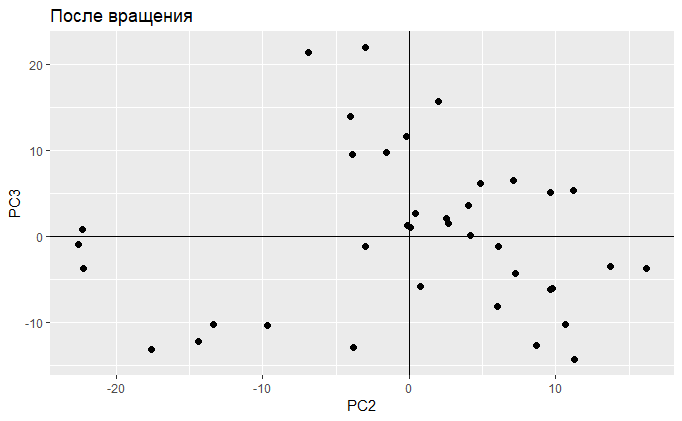

```r
library(ggplot2)
x_raw =t(golub)
X <- scale(x_raw, center = TRUE, scale = FALSE) # Центрируем
A <- cov(X)
E <- eigen(A)            # Спектральное разложение
U <- E$vectors           # Собственные векторы
Lambda <- E$values       # Собственные числа
dimnames(U) <- list(colnames(X),paste0("PC", 1:ncol(X)))
Y <- X %*% U # Координаты точек в новом пространстве
gg <- ggplot()+geom_point(size = 2)  +geom_hline(yintercept = 0) +
  geom_vline(xintercept = 0)+aes(x = PC2, y = PC3)
gg_rotated <- gg %+% as.data.frame(Y) +
  labs(title = "После вращения")
gg_rotated
```

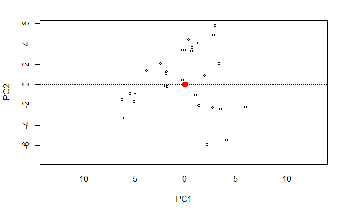

```r
library(vegan)
prot_pca <- rda(x_raw,
                scale = TRUE)
biplot(prot_pca)
```

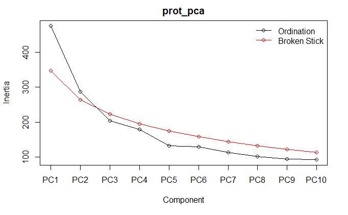

```r
screeplot(prot_pca, type = "lines", bstick = TRUE) # график собственных чисел
```

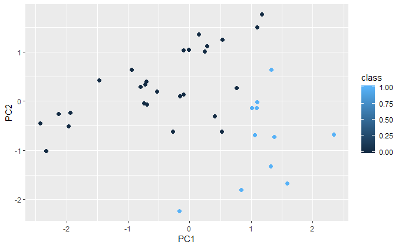

```r
gol_cl =as.matrix(golub.cl,ncol=1,byrow=T)
colnames(gol_cl)=c("class")
df_scores <- data.frame(gol_cl,
  scores(prot_pca, display = "sites", choices = c(1, 2, 3), scaling = "sites"))
p_scores <- ggplot(df_scores, aes(x = PC1, y = PC2)) +
  geom_point(size = 2,aes( colour = class))
p_scores
```

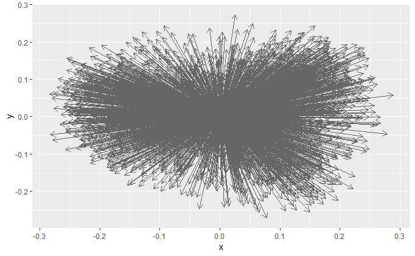

```r
df_load <- as.data.frame(scores(prot_pca, display = "species",
                                choices = c(1, 2, 3), scaling = "species"))
library(grid) # для стрелочек
ar <- arrow(length = unit(0.25, "cm"))
p_load <- ggplot(df_load) +
  geom_segment(aes(x = 0, y = 0, xend = PC1, yend = PC2),
               colour = "grey40", arrow = ar)
p_load
```

permanova

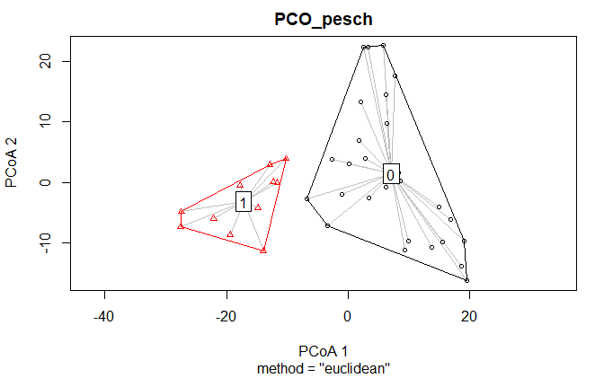

```r
library(vegan)
x=t(golub)
gol_cl =as.matrix(golub.cl,ncol=1,byrow=T)
colnames(gol_cl)=c("class")
colnames(x)=golub.gnames[,3]
x=cbind(x,Class=gol_cl)
x=as.data.frame(x)
#проверка внутригрупповых дисперсий
dist_pesch <- vegdist(x[,1:3051], method  = "euclidean")
PCO_pesch <- betadisper(dist_pesch, x$class)
plot(PCO_pesch)
```

```r
anova(PCO_pesch)
```

```
Analysis of Variance Table

Response: Distances
          Df Sum Sq Mean Sq F value  Pr(>F)
Groups     1  44.80  44.802  4.5011 0.04083 *
Residuals 36 358.33   9.954
---
Signif. codes:  0 ‘***’ 0.001 ‘**’ 0.01 ‘*’ 0.05 ‘.’ 0.1 ‘ ’ 1
```

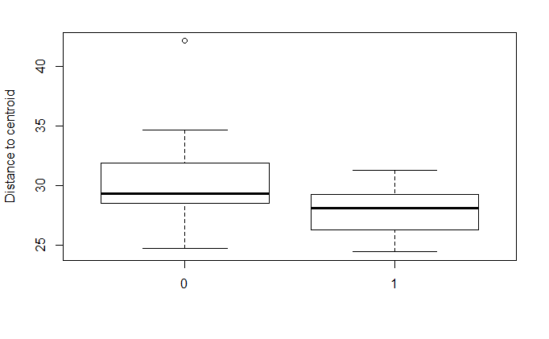

```r
boxplot(PCO_pesch)
```

```r
permanova_pesch <- adonis(x[1:3000] ~ x$class, method = "euclidian",permutations = 999)
permanova_pesch
```

```
Call:
adonis(formula = x[1:3000] ~ x$class, permutations = 999, method = "euclidian")

Permutation: free
Number of permutations: 999

Terms added sequentially (first to last)

          Df SumsOfSqs MeanSqs F.Model      R2 Pr(>F)
x$class    1      5021  5021.2  5.4983 0.13249  0.001 ***
Residuals 36     32876   913.2         0.86751
Total     37     37897                 1.00000
---
Signif. codes:  0 ‘***’ 0.001 ‘**’ 0.01 ‘*’ 0.05 ‘.’ 0.1 ‘ ’ 1
```

anosim manual

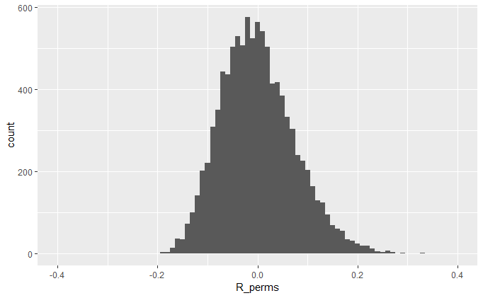

```r
library(ggplot2)
R_perm <- function(comm, group){
  require(vegan)
  dist_x <- vegdist(x, method = "euclidean")
  rank_dist_x<- rank(dist_x)
  dummy_dist <- dist(sample(as.numeric(group))) #Перемешиваем группы
  dummy_dist <- ifelse(dummy_dist == 0, 0, 1)
  dists <- data.frame(rank = rank_dist_x, dummy = as.vector(dummy_dist))
  require(dplyr)
  mean_dists <- dists %>% group_by(dummy) %>% summarize(rank_type = mean(rank))
  n <- nrow(x)
  R_perm <- (mean_dists$rank_type[2] - mean_dists$rank_type[1])/(n * (n - 1)/4)
  R_perm
}
R_perms <-  rep(NA, 10000)
dist_x <- vegdist(x, method = "euclidean")
rank_dist_x <- rank(dist_x)
dummy_dist <- dist(as.numeric(x$class))
dummy_dist <- ifelse(dummy_dist == 0, 0, 1)
dists <- data.frame(rank = rank_dist_x, dummy = as.vector(dummy_dist))
library(dplyr)
mean_dists <- dists %>% group_by(dummy) %>% summarize(rank_type = mean(rank))
n <- nrow(x)
R_glob <- (mean_dists$rank_type[2] - mean_dists$rank_type[1])/(n * (n - 1)/4)
for(i in 1:9999) R_perms[i] <- R_perm(comm = x, group = x$class)
R_perms[10000]=R_glob
Pl_manual <- ggplot(data.frame(R_perms), aes(x = R_perms)) +
  geom_histogram(binwidth = 0.01) +
  geom_vline(xintercept = R_glob, linetype = 2) + xlim(-0.4, 0.4)
Pl_manual
```

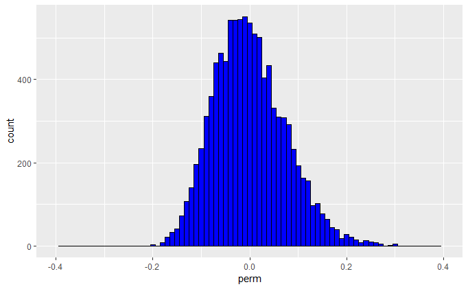

```r
library(ggplot2)
com_anosim <- anosim(x,
           grouping = x$class,
           permutations = 9999,
           distance = "euclidian")
anosim_perm <- data.frame(perm = com_anosim$perm)
anosim_perm[(com_anosim$permutations + 1), 1] <- com_anosim$statistic
Pl_prof <- ggplot(anosim_perm, aes(x = perm)) +
  geom_histogram(binwidth = 0.01, color = "black", fill = "blue") +
  geom_vline(xintercept = com_anosim$statistic, linetype = 2)  + xlim(-0.4, 0.4)
Pl_prof
```

```r
summary(com_anosim)
```

```
Call:
anosim(x = x, grouping = x$class, permutations = 9999, distance = "euclidian")
Dissimilarity: euclidean

ANOSIM statistic R: 0.5299
      Significance: 1e-04

Permutation: free
Number of permutations: 9999

Upper quantiles of permutations (null model):
   90%    95%  97.5%    99%
0.0997 0.1321 0.1613 0.2034

Dissimilarity ranks between and within classes:
        0%   25% 50% 75% 100%   N
Between 49 320.0 492 606  703 297
0        1 120.5 270 436  686 351
1       15  74.5 144 289  508  55
```

Результаты anosim

```r
summary(com_anosim)
```

```
Call:
anosim(x = x, grouping = x$class, permutations = 9999, distance = "euclidian")
Dissimilarity: euclidean

ANOSIM statistic R: 0.5299
      Significance: 1e-04

Permutation: free
Number of permutations: 9999

Upper quantiles of permutations (null model):
   90%    95%  97.5%    99%
0.0997 0.1321 0.1613 0.2034

Dissimilarity ranks between and within classes:
        0%   25% 50% 75% 100%   N
Between 49 320.0 492 606  703 297
0        1 120.5 270 436  686 351
1       15  74.5 144 289  508  55
```

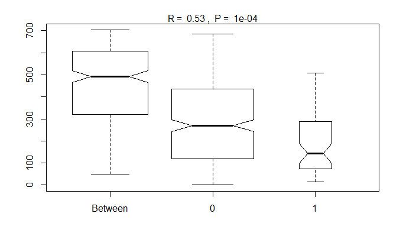

```r
plot(com_anosim)
```

Семантическая близость, достаём граф GOSIm

```r
library(igraph)
library(GOSim)
library(hu6800.db)
 data("ICsBPhumanall")
db=hu6800.db
data("ICsBPhumanall")
othman_a =0.5
othman_b=0.5
probe_gene_A= "AFFX-HUMISGF3A/M97935_MB_at"
probe_gene_B= "AFFX-HUMISGF3A/M97935_MA_at"
par_GO=getParents()
anc_GO = getAncestors()
res_sel_A = AnnotationDbi::select(db,keys =probe_gene_A ,columns = c("PROBEID","ENTREZID","GO"))
GOs_A = dplyr::filter(res_sel_A[3], res_sel_A[5]=="BP" )
GOs_A=unlist(GOs_A)
res_sel_B = AnnotationDbi::select(db,keys =probe_gene_B,columns = c("PROBEID","ENTREZID","GO"))
GOs_B = dplyr::filter(res_sel_B[3], res_sel_B[5]=="BP" )
GOs_B=unlist(GOs_B)
cat("анализ генов: \n",
    probe_gene_A, " термов: ", length(GOs_A),"\n",
    probe_gene_B, " термов: ", length(GOs_B),"\n=======\n"  )
```

```
анализ генов:
 AFFX-HUMISGF3A/M97935_MB_at  термов:  54
 AFFX-HUMISGF3A/M97935_MA_at  термов:  54
=======
```

```r
probe_dist=Inf
for(i in 1:length(GOs_A)){
  for (j in 1:length(GOs_B)) {

    G=getGOGraph(c(GOs_A[i],GOs_B[j]))
    cat("пара термов:", i, "   " , j, "\n",
        "размер графа: ",length(G@nodes) ," узлов ", length(G@edgeData@data)  ," рёбер\n")
    DAG=igraph.from.graphNEL(G)
    e_mean=length(G@edgeData@data)/length(G@nodes)
    anc_A= anc_GO[GOs_A[i]]
    anc_B= anc_GO[GOs_B[j]]
    anc_com= intersect(anc_A[[1]],anc_B[[1]])
    stack_df= data.frame(c(GOs_A[i],GOs_B[j]),stringsAsFactors =F)
    names(stack_df)=c("GOs")
    stack_pointer=1
    sum_dist=0
    while (nrow(stack_df)>=stack_pointer) {

      c_node=stack_df$GOs[stack_pointer]
      rod= ego(graph = DAG,nodes = c_node,mode = "out",mindist = 1)
       # cat("node", c_node," родителей ", length(rod[[1]]), "\n")
      for (p_node in names(rod[[1]])) {
        e_loc= length(ego(graph = DAG,nodes = p_node,mode = "in", mindist=1)[[1]])
        d_p=distances(graph = DAG,v = p_node,to = "all")
        t_cp=1
        if (p_node%in% par_GO[[c_node]][grep("is_a",names( par_GO[[c_node]]))]){
          t_cp=0.8
        }
          if (p_node%in% par_GO[[c_node]][grep("part_of",names( par_GO[[c_node]]))]){
          t_cp=0.6
        }
        w=(othman_b+(1-othman_b)*e_mean/e_loc)*(((d_p+1)/d_p)**othman_a)*(IC[c_node]-IC[p_node])*t_cp
        if(!is.na(w)&(w!=Inf) &(w!=-Inf)){
           #cat(p_node," w = ", w, " dist ", sum_dist, "\n")
          sum_dist=sum_dist+w
          if (!(p_node%in%anc_com ) & !(p_node%in%stack_df$GOs)) {
              stack_df=rbind(stack_df,p_node)
          }
        }
      }
    stack_pointer=stack_pointer+1
    }

    cat("term dist " , sum_dist , "\n ================\n")

    probe_dist=min(sum_dist,probe_dist)
    sum_dist=0
  }
}
```

```
Node names may not be duplicated
```

```
Error in validObject(.Object) : invalid class “graphNEL” object: FALSE
```

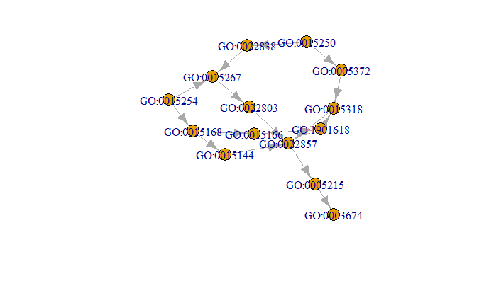

```r
library(GOstats)
library("hu6800.db")
set.seed(321)
gN <- unique(sample(keys(hu6800.db, 'ENTREZID'), 4))
gg1 <- makeGOGraph(c("360"), "MF", chip="hu6800.db")
g=igraph.from.graphNEL(gg1)
  plot(g, vertex.label=V(g)$name)
```

types of relation in GO

```r
library(GO.db)
x=GOCCPARENTS
x= as.list(x)
print(x["GO:0005737"])
```

```
$`GO:0005737`
        is_a
"GO:0044424"
```

честный минимум

```r
data(golub)
db=hu6800.db
columns(db)
```

```
 [1] "ACCNUM"       "ALIAS"        "ENSEMBL"      "ENSEMBLPROT"  "ENSEMBLTRANS" "ENTREZID"
 [7] "ENZYME"       "EVIDENCE"     "EVIDENCEALL"  "GENENAME"     "GO"           "GOALL"
[13] "IPI"          "MAP"          "OMIM"         "ONTOLOGY"     "ONTOLOGYALL"  "PATH"
[19] "PFAM"         "PMID"         "PROBEID"      "PROSITE"      "REFSEQ"       "SYMBOL"
[25] "UCSCKG"       "UNIGENE"      "UNIPROT"
```

```r
d_set =golub
data("ICsBPhumanall")
par_GO=getParents()
anc_GO = getAncestors()
rownames(d_set)=golub.gnames[,3]
res_sel = AnnotationDbi::select(db,keys =golub.gnames[,3] ,columns = c("PROBEID","GO"))
good_ids =unique (dplyr::filter(res_sel[1],!is.na(res_sel[2])&!is.na(res_sel[3])& res_sel[4]=="BP" ) )
entr_sel=AnnotationDbi::select(db,keys =golub.gnames[,3] ,columns = c("PROBEID","ENTREZID"))
print(length(golub.gnames[,3]))
```

```
[1] 3051
```

```r
cat("проб с entrez_id ",length(good_ids$PROBEID),"\n")
```

```
проб с entrez_id  2768
```

```r
d_set= d_set[unlist(good_ids$PROBEID),]
dist_matr_min= matrix(nrow = nrow(d_set),ncol = nrow(d_set),dimnames = list(rownames(d_set),rownames(d_set)))
dist_matr_sum= matrix(nrow = nrow(d_set),ncol = nrow(d_set),dimnames = list(rownames(d_set),rownames(d_set)))
```

делаем большой граф и пересекаем потомков

```r
library(igraph)
library(GOSim)
library(hu6800.db)
library(multtest)
data(golub)
db=hu6800.db
columns(db)
```

```
 [1] "ACCNUM"       "ALIAS"        "ENSEMBL"      "ENSEMBLPROT"  "ENSEMBLTRANS" "ENTREZID"
 [7] "ENZYME"       "EVIDENCE"     "EVIDENCEALL"  "GENENAME"     "GO"           "GOALL"
[13] "IPI"          "MAP"          "OMIM"         "ONTOLOGY"     "ONTOLOGYALL"  "PATH"
[19] "PFAM"         "PMID"         "PROBEID"      "PROSITE"      "REFSEQ"       "SYMBOL"
[25] "UCSCKG"       "UNIGENE"      "UNIPROT"
```

```r
d_set =golub
data("ICsBPhumanall")
par_GO=getParents()
anc_GO = getAncestors()
gene_sim=function(probe_gene_A,probe_gene_B,othman_a,othman_b){
    res_sel_A = AnnotationDbi::select(db,keys =probe_gene_A ,columns = c("PROBEID","GO"))
    GOs_A = dplyr::filter(res_sel_A[2], res_sel_A[4]=="BP" )
    GOs_A=unlist(GOs_A)
    res_sel_B = AnnotationDbi::select(db,keys =probe_gene_B,columns = c("PROBEID","GO"))
    GOs_B = dplyr::filter(res_sel_B[2], res_sel_B[4]=="BP" )
    GOs_B=unlist(GOs_B)

    probe_dist=Inf
    anc_com =c("GO:0008150")
    all_GOs=union( GOs_A,GOs_B)
    G=getGOGraph(all_GOs)
    e_mean=length(G@edgeData@data)/length(G@nodes)
    DAG=igraph.from.graphNEL(G)
    for(i in 1:length(GOs_A)){
        for (j in 1:length(GOs_B)) {
          anc_A= anc_GO[GOs_A[i]]
          anc_B= anc_GO[GOs_B[j]]
          anc_com= union(anc_com,intersect(anc_A[1],anc_B[1]))
        }
    }
            stack_df= data.frame(all_GOs,stringsAsFactors =F)
            names(stack_df)=c("GOs")
            stack_pointer=1
            sum_dist=0
            while (nrow(stack_df)>=stack_pointer) {
              c_node=stack_df$GOs[stack_pointer]
              rod= ego(graph = DAG,nodes = c_node,mode = "out",mindist = 1)
              for (p_node in names(rod[[1]])) {
                e_loc= length(ego(graph = DAG,nodes = p_node,mode = "in", mindist=1)[[1]])
                d_p=distances(graph = DAG,v = p_node,to = "all")
                t_cp=1
                if (p_node%in% par_GO[[c_node]][grep("is_a",names( par_GO[[c_node]]))]){
                  t_cp=0.8
                }
                  if (p_node%in% par_GO[[c_node]][grep("part_of",names( par_GO[[c_node]]))]){
                  t_cp=0.6
                }
                w=(othman_b+(1-othman_b)*e_mean/e_loc)*(((d_p+1)/d_p)**othman_a)*(IC[c_node]-IC[p_node])*t_cp
                if(!is.na(w)&(w!=Inf) &(w!=-Inf)){
                  sum_dist=sum_dist+w
                  if (!(p_node%in%anc_com ) & !(p_node%in%stack_df$GOs)) {
                      stack_df=rbind(stack_df,p_node)
                  }
                }
              }
            stack_pointer=stack_pointer+1
            }


        probe_dist=sum_dist
        cat(probe_dist,"\n")
    return(probe_dist)

}
rownames(d_set)=golub.gnames[,3]
res_sel = AnnotationDbi::select(db,keys =golub.gnames[,3] ,columns = c("PROBEID","GO"))
good_ids =unique (dplyr::filter(res_sel[1],!is.na(res_sel[2])&!is.na(res_sel[3]) ) )
entr_sel=AnnotationDbi::select(db,keys =golub.gnames[,3] ,columns = c("PROBEID","ENTREZID"))
print(length(golub.gnames[,3]))
```

```
[1] 3051
```

```r
cat("проб с entrez_id ",length(good_ids$PROBEID),"\n")
```

```
проб с entrez_id  2811
```

```r
d_set= d_set[unlist(good_ids$PROBEID),]
dist_matr= matrix(nrow = nrow(d_set),ncol = nrow(d_set),dimnames = list(rownames(d_set),rownames(d_set)))
start_time= proc.time()
for (i in (1:length(good_ids$PROBEID))) {
  cat("========= gene ", i, " ==========\n")
  for (j in i:length(good_ids$PROBEID)) {
    gene_A=rownames(d_set)[i]
    gene_B=rownames(d_set)[j]
    cat("гены ",gene_A,", ",gene_B,": ", i, ", ",j ,"\n")
    if (i==j){
      dist_matr[gene_A,gene_B]= 0
    }
    else{
    dist_matr[gene_A,gene_B]= gene_sim(probe_gene_A = gene_A,probe_gene_B = gene_B,othman_a = 0.5,othman_b = 0.5)
    }
    print(proc.time()-start_time)
  }

}
```

```
========= gene  1  ==========
гены  AFFX-HUMISGF3A/M97935_MA_at ,  AFFX-HUMISGF3A/M97935_MA_at :  1 ,  1
   user  system elapsed
   0.11    0.03    0.50
гены  AFFX-HUMISGF3A/M97935_MA_at ,  AFFX-HUMISGF3A/M97935_MB_at :  1 ,  2
```

```
657.8963
   user  system elapsed
   4.66    0.15    5.36
гены  AFFX-HUMISGF3A/M97935_MA_at ,  AFFX-HUMISGF3A/M97935_3_at :  1 ,  3
```

```
657.8963
   user  system elapsed
   8.75    0.33    9.78
гены  AFFX-HUMISGF3A/M97935_MA_at ,  AFFX-HUMGAPDH/M33197_5_at :  1 ,  4
```

```
1090.138
   user  system elapsed
  13.36    0.47   14.68
гены  AFFX-HUMISGF3A/M97935_MA_at ,  AFFX-HUMGAPDH/M33197_M_at :  1 ,  5
```

```
1090.138
   user  system elapsed
  17.59    0.67   19.23
гены  AFFX-HUMISGF3A/M97935_MA_at ,  AFFX-HSAC07/X00351_5_at :  1 ,  6
```

```
798.9049
   user  system elapsed
  21.16    0.80   23.11
гены  AFFX-HUMISGF3A/M97935_MA_at ,  AFFX-HSAC07/X00351_M_at :  1 ,  7
```

```
798.9049
   user  system elapsed
  24.51    0.94   26.78
гены  AFFX-HUMISGF3A/M97935_MA_at ,  AFFX-HUMTFRR/M11507_5_at :  1 ,  8
```

```
921.9141
   user  system elapsed
  28.28    1.08   30.86
гены  AFFX-HUMISGF3A/M97935_MA_at ,  AFFX-HUMTFRR/M11507_M_at :  1 ,  9
```

```
921.9141
   user  system elapsed
  31.97    1.25   34.84
гены  AFFX-HUMISGF3A/M97935_MA_at ,  AFFX-HUMTFRR/M11507_3_at :  1 ,  10
```

```
921.9141
   user  system elapsed
  35.59    1.45   38.79
гены  AFFX-HUMISGF3A/M97935_MA_at ,  AFFX-HSAC07/X00351_3_st :  1 ,  11
```

```
798.9049
   user  system elapsed
  39.03    1.53   42.48
гены  AFFX-HUMISGF3A/M97935_MA_at ,  AFFX-HUMGAPDH/M33197_M_st :  1 ,  12
```

```
1090.138
   user  system elapsed
  43.26    1.65   47.03
гены  AFFX-HUMISGF3A/M97935_MA_at ,  AFFX-HUMGAPDH/M33197_3_st :  1 ,  13
```

```
1090.138
   user  system elapsed
  47.75    1.83   51.81
гены  AFFX-HUMISGF3A/M97935_MA_at ,  AFFX-HSAC07/X00351_M_st :  1 ,  14
```

наиболее информативный

```r
library(igraph)
library(GOSim)
library(hu6800.db)
library(multtest)
data(golub)
db=hu6800.db
columns(db)
```

```
 [1] "ACCNUM"       "ALIAS"        "ENSEMBL"      "ENSEMBLPROT"  "ENSEMBLTRANS" "ENTREZID"
 [7] "ENZYME"       "EVIDENCE"     "EVIDENCEALL"  "GENENAME"     "GO"           "GOALL"
[13] "IPI"          "MAP"          "OMIM"         "ONTOLOGY"     "ONTOLOGYALL"  "PATH"
[19] "PFAM"         "PMID"         "PROBEID"      "PROSITE"      "REFSEQ"       "SYMBOL"
[25] "UCSCKG"       "UNIGENE"      "UNIPROT"
```

```r
d_set =golub
data("ICsBPhumanall")
par_GO=getParents()
anc_GO = getAncestors()
rownames(d_set)=golub.gnames[,3]
res_sel = AnnotationDbi::select(db,keys =golub.gnames[,3] ,columns = c("PROBEID","GO"))
good_ids =unique (dplyr::filter(res_sel[1],!is.na(res_sel[2])&!is.na(res_sel[3])& res_sel[4]=="BP" ) )
entr_sel=AnnotationDbi::select(db,keys =golub.gnames[,3] ,columns = c("PROBEID","ENTREZID"))
cat("проб с entrez_id ",length(good_ids$PROBEID),"\n")
```

```
проб с entrez_id  2768
```

```r
d_set= d_set[unlist(good_ids$PROBEID),]
dist_matr_max= matrix(nrow = nrow(d_set),ncol = nrow(d_set),dimnames = list(rownames(d_set),rownames(d_set)))
gene_sim=function(probe_gene_A,probe_gene_B,othman_a,othman_b){
    res_sel_A = AnnotationDbi::select(db,keys =probe_gene_A ,columns = c("PROBEID","GO"))
    GOs_A = unique(dplyr::filter(res_sel_A[2], res_sel_A[4]=="BP" ))
    GOs_A=unlist(GOs_A)
    res_sel_B = AnnotationDbi::select(db,keys =probe_gene_B,columns = c("PROBEID","GO"))
    GOs_B = unique(dplyr::filter(res_sel_B[2], res_sel_B[4]=="BP" ))
    GOs_B=unlist(GOs_B)
    max_a=GOs_A[1]
    for (go_a in GOs_A) {
      if(!is.na(IC[go_a])&IC[go_a]!=Inf){
        if(IC[go_a]>IC[max_a]){
          max_a=go_a
        }
      }
    }
    max_b=GOs_B[1]
    for (go_b in GOs_B) {
      if(!is.na(IC[go_b])&IC[go_b]!=Inf){
            if(IC[go_b]>IC[max_b]){
            max_b=go_b
          }
      }
    }
    probe_dist=0
    G=getGOGraph(max_a,max_b)
    DAG=igraph.from.graphNEL(G)
    e_mean=length(G@edgeData@data)/length(G@nodes)
    sum_dist=0
        if(max_a==max_b){
          sum_dist=0
        }
    else{
            anc_A= anc_GO[max_a]
            anc_B= anc_GO[max_b]
            anc_com= intersect(anc_A[[1]],anc_B[[1]])
            # stack_df= data.frame(c(GOs_A[i],GOs_B[j]),stringsAsFactors =F)
            stack_list=c(max_a,max_b)
            # names(stack_df)=c("GOs")
            stack_pointer=1
            while (length(stack_list)>=stack_pointer) {
              # c_node=stack_df$GOs[stack_pointer]
              tryCatch( { c_node=stack_list[stack_pointer]
                      rod= ego(graph = DAG,nodes = c_node,mode = "out",mindist = 1)
                      d_c=distances(graph = DAG,v = c_node,to = "all")
                      for (p_node in names(rod[[1]])) {
                        e_loc= length(ego(graph = DAG,nodes = p_node,mode = "in", mindist=1)[[1]])
                        d_p=d_c-1
                        t_cp=1
                        if (p_node%in% par_GO[[c_node]][grep("is_a",names( par_GO[[c_node]]))]){
                          t_cp=0.8
                        }
                        if (p_node%in% par_GO[[c_node]][grep("part_of",names( par_GO[[c_node]]))]){
                          t_cp=0.6
                        }
                        w=(othman_b+(1-othman_b)*e_mean/e_loc)*(((d_p+1)/d_p)**othman_a)*(IC[c_node]-IC[p_node])*t_cp
                        if(!is.na(w)&(w!=Inf) &(w!=-Inf)){
                          sum_dist=sum_dist+w
                          if (!(p_node%in%anc_com )) {
                            if(  !(p_node%in%stack_list)){
                              # stack_df=rbind(stack_df,p_node)
                              stack_list=c(stack_list,p_node)
                            }
                          }
                        }
                      }
              },
              error=function(cond){
                  message("qwerty")
                sum_dist=NA
                return(NULL)
              })
            stack_pointer=stack_pointer+1
            }
        }
        probe_dist=sum_dist
        print(probe_dist)
    return(probe_dist)
}
start_time= proc.time()
for (i in (1:length(good_ids$PROBEID))) {
  cat("========= gene ", i, " ==========\n")
  for (j in i:length(good_ids$PROBEID)) {
    gene_A=rownames(d_set)[i]
    gene_B=rownames(d_set)[j]
    cat("гены ",gene_A,", ",gene_B,": ", i, ", ",j ,"\n")
    if (i==j){
      dist_matr_max[gene_A,gene_B]=0
    }
    else{
    dist_matr_max[gene_A,gene_B]= gene_sim(probe_gene_A = gene_A,probe_gene_B = gene_B,othman_a = 0.5,othman_b = 0.5)
    }
    print(proc.time()-start_time)
  }

}
```

```
========= gene  1  ==========
гены  AFFX-HUMISGF3A/M97935_MA_at ,  AFFX-HUMISGF3A/M97935_MA_at :  1 ,  1
   user  system elapsed
   0.04    0.03    0.36
гены  AFFX-HUMISGF3A/M97935_MA_at ,  AFFX-HUMISGF3A/M97935_MB_at :  1 ,  2
```

```
[1] 0
   user  system elapsed
   0.92    0.23    1.52
гены  AFFX-HUMISGF3A/M97935_MA_at ,  AFFX-HUMISGF3A/M97935_3_at :  1 ,  3
```

```
[1] 0
   user  system elapsed
   1.75    0.45    2.69
гены  AFFX-HUMISGF3A/M97935_MA_at ,  AFFX-HUMGAPDH/M33197_5_at :  1 ,  4
```

```
qwerty
```

```
                all
GO:0038113 28.11931
   user  system elapsed
   2.58    0.65    3.88
гены  AFFX-HUMISGF3A/M97935_MA_at ,  AFFX-HUMGAPDH/M33197_M_at :  1 ,  5
```

```
qwerty
```

```
                all
GO:0038113 28.11931
   user  system elapsed
   3.34    0.87    5.05
гены  AFFX-HUMISGF3A/M97935_MA_at ,  AFFX-HSAC07/X00351_5_at :  1 ,  6
```

```
qwerty
```

```
                all
GO:0038113 28.42345
   user  system elapsed
   4.64    1.06    6.67
гены  AFFX-HUMISGF3A/M97935_MA_at ,  AFFX-HSAC07/X00351_M_at :  1 ,  7
```

```
qwerty
```

```
                all
GO:0038113 28.42345
   user  system elapsed
   5.47    1.20    7.83
гены  AFFX-HUMISGF3A/M97935_MA_at ,  AFFX-HUMTFRR/M11507_5_at :  1 ,  8
```

```
qwerty
```

```
                all
GO:0038113 28.42345
   user  system elapsed
   6.34    1.42    9.06
гены  AFFX-HUMISGF3A/M97935_MA_at ,  AFFX-HUMTFRR/M11507_M_at :  1 ,  9
```